# Linear Regression

KwH. Kim

2018년 11월 9일

## 기초 통계학

- 통계학의 두 가지 주제: 서술 통계(descriptive statistics), 추론 통계(inferential statistics)
- 모집단(population)/표본(sample)
- 모수(parameter)/추정량(estimator)
- 모수의 예
  - 통계 요약치
    - 집중경향치 : 평균(mean), 중앙값(median), 최빈값(mode), 절사평균(trimmed mean)
    - 변산성 측정치 : 범위(range), 사분점간 범위(inter-quartile range), 분산(variance)
- 모평균의 추정방법(모평균 추정량)
  - 표본 평균
  - 표본 중앙값
- 추정량의 좋은 성질
  - 비편향성(unbiasedness)
    - 편향적인 추정량의 예 : $\sum_{i=1}^n \frac{(X_i - \bar{X})^2}{n}$
  - 일치성(consistency)
  - 효율성(efficiency)
- 가설 검정
  - 영가설(귀무가설; null hypothesis), 검정통계량(test statistics)
  - 유의수준(significance level), 오류율(error rate), 기각역(critical region)
  - 효과크기(effect size)
  - 검정력(power)

## 예: 모평균 추정하기

```r
getwd()
## [1] "G:/git/MJU-2018-02-DataScience/00_Instructor/W11_MultipleRegression"
dat <- read.csv(file='./LR_weight_n100.csv', header=T, row.names=1)
t.test(dat$height)
##
##  One Sample t-test
##
## data:  dat$height
## t = 204.3, df = 99, p-value < 2.2e-16
## alternative hypothesis: true mean is not equal to 0
## 95 percent confidence interval:
##  166.2817 169.5433
## sample estimates:
## mean of x
##  167.9125
t.test(dat$weight)
##
##  One Sample t-test
##
## data:  dat$weight
## t = 35.635, df = 99, p-value < 2.2e-16
## alternative hypothesis: true mean is not equal to 0
## 95 percent confidence interval:
##  69.84168 78.07820
## sample estimates:
## mean of x
##  73.95994
```

## 예: 모평균의 차이 추정하기

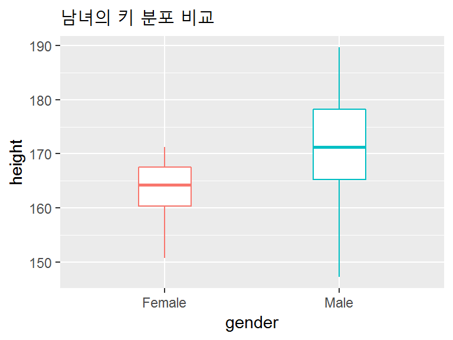

```r
t.test(height ~ gender, dat)
##
##  Welch Two Sample t-test
##
## data:  height by gender
## t = -5.8198, df = 90.205, p-value = 8.887e-08
## alternative hypothesis: true difference in means is not equal to 0
## 95 percent confidence interval:
##  -10.77773  -5.29217
## sample estimates:
## mean in group F mean in group M
##        163.4933        171.5282
t.test(weight ~ gender, dat)
##
##  Welch Two Sample t-test
##
## data:  weight by gender
## t = -11.089, df = 96.576, p-value < 2.2e-16
## alternative hypothesis: true difference in means is not equal to 0
## 95 percent confidence interval:
##  -35.98621 -25.05924
## sample estimates:
## mean in group F mean in group M
##        57.17244        87.69517

ggplot(dat, aes(x=gender, y=height, col=gender)) +
  #geom_point(alpha=0.2, col='black') +
  geom_boxplot(width=0.3) +
  #geom_boxplot(width=0.3, alpha=0.2) +
  guides(colour='none', fill='none') +
  scale_x_discrete(labels=c('Female', 'Male')) +
  labs(title='남녀의 키 분포 비교')
```

## 회귀(Regression) 분석(Analysis)

- 독립변수(independent variable), 종속변수(dependent variable)
- 설명변수(Explanatory variable), 반응변수(Response variable)
- 예측변수(Predictor variable), 결과변수(Outcome variable)

$$\mathbb{E}[Y | x_1, x_2, ..., x_p] = f(x_1, x_2, ..., x_p)$$

## 단순선형회귀(Simple Linear Regression) 분석

### 모형

$$y= \beta_0 + \beta_1 x + e, e \sim N(0, \sigma^2)$$
$$E[Y | x] = \beta_0 + \beta_1 x + e$$

### 가정(LINE)

- **L**inearity(선형성) : 예측변수(predictor)가 1 증가할 때, 결과변수(outcome variable) 평균의 증가는 일정하다.
- **I**ndependence(독립성) : 예측변수의 값이 주어졌을 때, 결과변수의 분포는 다른 결과변수와 독립이다.
- **N**ormality(정규성) : 오차의 분포는 정규분포이다.
- **E**qual variance(등분산성) : 오차의 분포는 등분산(homoscedasticity)이다. 이분산(heteroscedasticity)이 아니다.

### 예: 키로 체중 예측하기

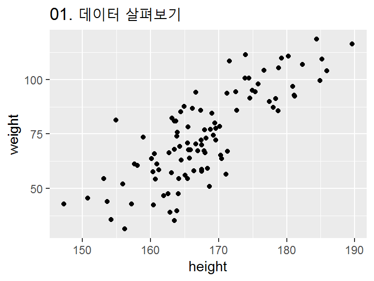

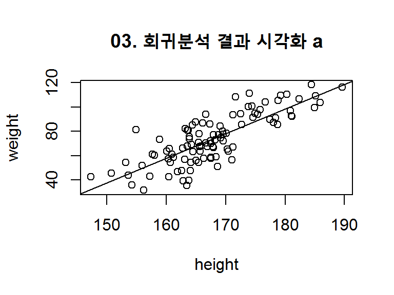

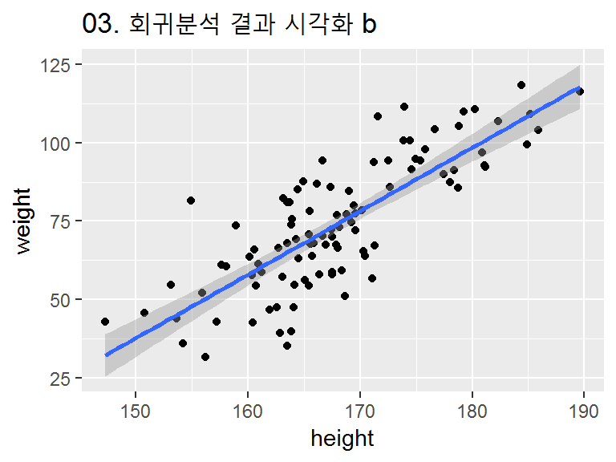

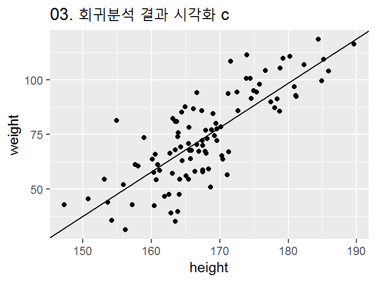

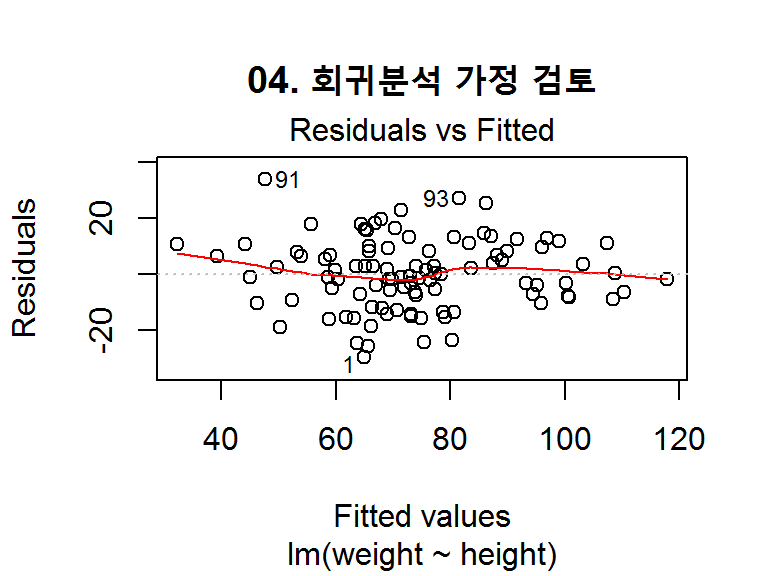

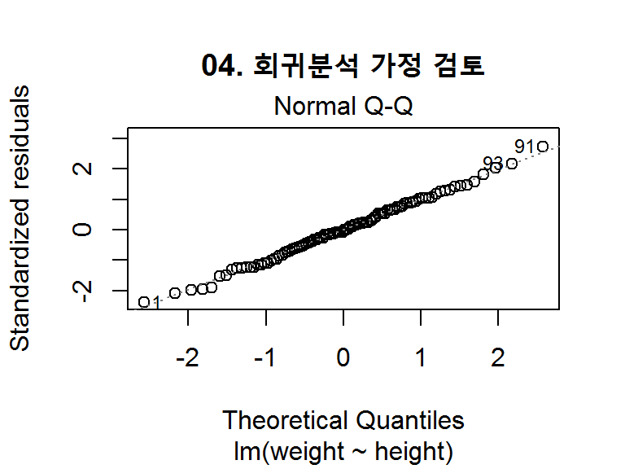

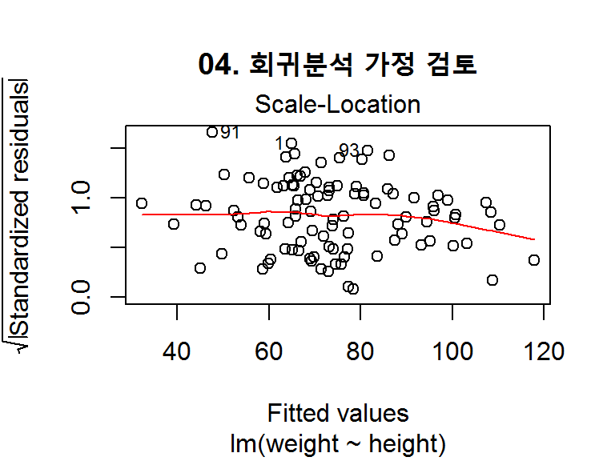

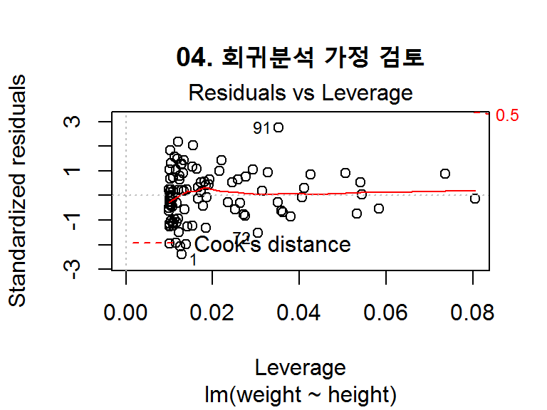

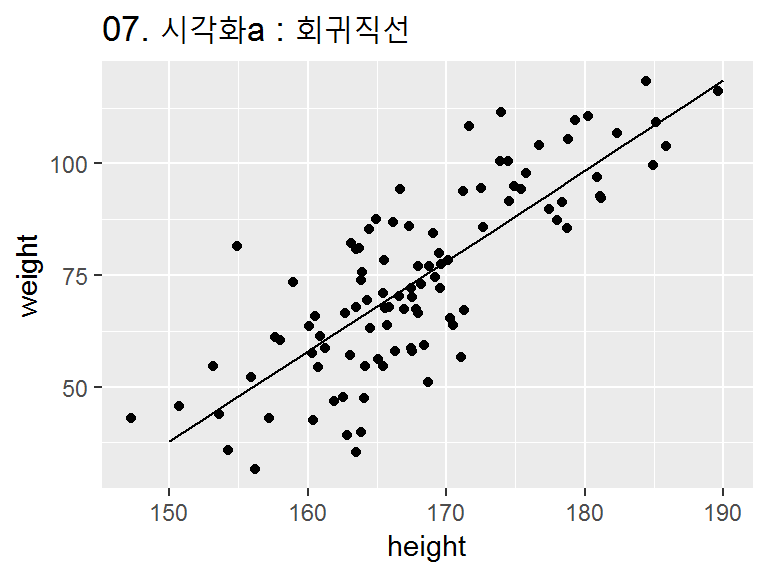

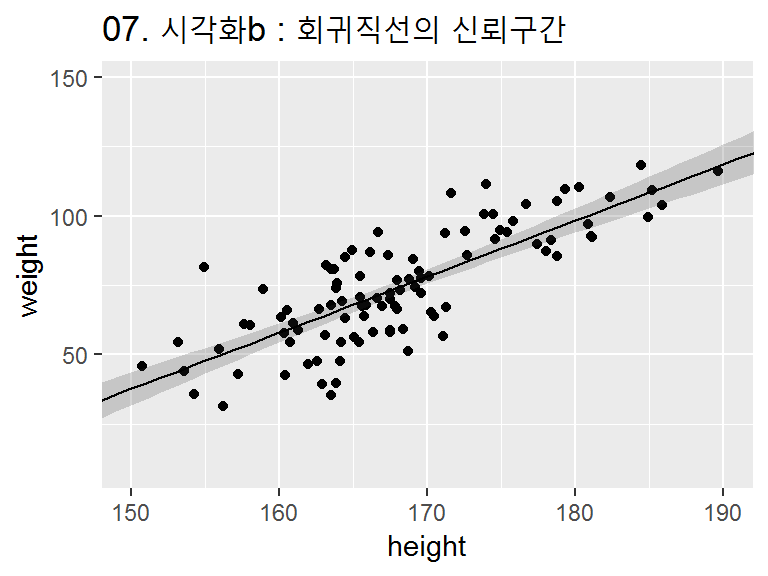

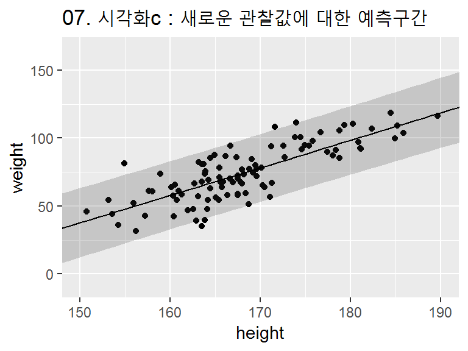

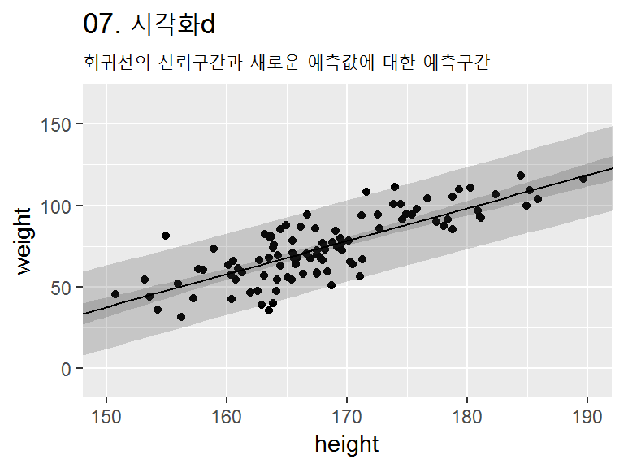

```r
library(ggplot2)
library(dplyr)
##
## Attaching package: 'dplyr'
## The following objects are masked from 'package:stats':
##
##     filter, lag
## The following objects are masked from 'package:base':
##
##     intersect, setdiff, setequal, union
library(tidyr)
getwd()
## [1] "G:/git/MJU-2018-02-DataScience/00_Instructor/W11_MultipleRegression"
dat <- read.csv(file='./LR_weight_n100.csv', header=T, row.names=1)

# 01. 데이터 살펴보기
ggplot(dat, aes(x=height, y=weight)) + geom_point() + labs(title="01. 데이터 살펴보기")

# 02. 회귀분석
fitLm <- lm(weight ~ height, dat)
print(fitLm)
##
## Call:
## lm(formula = weight ~ height, data = dat)
##
## Coefficients:
## (Intercept)       height
##    -265.684        2.023
print(summary(fitLm))
##
## Call:
## lm(formula = weight ~ height, data = dat)
##
## Residuals:
##     Min      1Q  Median      3Q     Max
## -29.713  -7.984  -0.474   8.497  33.696
##
## Coefficients:
##              Estimate Std. Error t value Pr(>|t|)
## (Intercept) -265.6840    25.6719  -10.35   <2e-16 ***
## height         2.0227     0.1527   13.25   <2e-16 ***
## ---
## Signif. codes:  0 '***' 0.001 '**' 0.01 '*' 0.05 '.' 0.1 ' ' 1
##
## Residual standard error: 12.49 on 98 degrees of freedom
## Multiple R-squared:  0.6416, Adjusted R-squared:  0.638
## F-statistic: 175.5 on 1 and 98 DF,  p-value: < 2.2e-16

# 03. 회귀분석 결과를 시각화하기
## a
plot(weight ~ height, dat, main='03. 회귀분석 결과 시각화 a'); abline(fitLm)

## b
ggplot(dat, aes(x=height, y=weight)) + geom_point() +
  geom_smooth(method="lm") + labs(title='03. 회귀분석 결과 시각화 b')

## c
ggplot(dat, aes(x=height, y=weight)) + geom_point() +
  geom_abline(intercept = fitLm$coefficients["(Intercept)"],
              slope = fitLm$coefficients["height"]) +
  labs(title='03. 회귀분석 결과 시각화 c')

# 04. 회귀분석 가정 검토
#par(mfrow=c(2,2),oma = c(0, 0, 2, 0))
plot(fitLm, main='04. 회귀분석 가정 검토') # plot(fitLm, which=1:6)
## a. x와 y의 관계가 선형적인가?
## b. 잔차가 정규성을 띄는가?
## c. 잔차가 등분산인가?
## d. 특이값(계수 추정에 큰 영향을 미치는 값)이 존재하는가?

# 05. 계수의 추정값과 신뢰구간
confint(fitLm)
##                   2.5 %      97.5 %
## (Intercept) -316.629001 -214.738960
## height         1.719701    2.325787
confint(fitLm, level=0.99)
##                   0.5 %      99.5 %
## (Intercept) -333.122254 -198.245708
## height         1.621592    2.423896

# 06. 새로운 predictor에 대한 예상값 구하기
newdat = data.frame(height=c(160, 170, 180))
predict(fitLm, newdat)
##        1        2        3
## 57.95499 78.18243 98.40986
predict(fitLm, newdat, interval="confidence") # 회귀선
##        fit      lwr       upr
## 1 57.95499 54.50662  61.40337
## 2 78.18243 75.62471  80.74014
## 3 98.40986 93.98725 102.83248
predict(fitLm, newdat, interval="prediction") # 새로운 관찰
##        fit      lwr       upr
## 1 57.95499 32.93374  82.97624
## 2 78.18243 53.26830 103.09655
## 3 98.40986 73.23584 123.58388

# 07. 시각화
## 07a
newdat = data.frame(height=150:190)
newy <- predict(fitLm, newdat)
datPred <- cbind(newdat, newy)
ggplot(dat, aes(x=height, y=weight)) + geom_point() +
  geom_line(data=datPred, aes(x=height, y=newy)) +
  labs(title='07. 시각화a : 회귀직선')

## 07b
newdat = data.frame(height=140:200)
newy <- predict(fitLm, newdat, interval="confidence")
datPred <- cbind(newdat, newy)
ggplot(dat, aes(x=height, y=weight)) + geom_point() +
  geom_ribbon(data=datPred, aes(x=height, y=fit, ymin=lwr, ymax=upr), alpha=0.2) +
  geom_line(data=datPred, aes(x=height, y=fit)) +
  coord_cartesian(xlim=c(150,190))+
  labs(title='07. 시각화b : 회귀직선의 신뢰구간')
## Warning: Ignoring unknown aesthetics: y

## 07c
newdat = data.frame(height=140:200)
newy <- predict(fitLm, newdat, interval="prediction")
datPred <- cbind(newdat, newy)
ggplot(dat, aes(x=height, y=weight)) + geom_point() +
  geom_ribbon(data=datPred, aes(x=height, y=fit, ymin=lwr, ymax=upr), alpha=0.2) +
  geom_line(data=datPred, aes(x=height, y=fit)) +
  coord_cartesian(xlim=c(150,190)) +
  labs(title='07. 시각화c : 새로운 관찰값에 대한 예측구간')
## Warning: Ignoring unknown aesthetics: y

## 07d
newdat = data.frame(height=140:200)
yconf <- data.frame(predict(fitLm, newdat, interval="confidence"))
ypred <- data.frame(predict(fitLm, newdat, interval="prediction"))
ypred$height <- yconf$height <- newdat$height
datPred <- full_join(yconf, ypred, by=c('height', 'fit'))
ggplot(dat, aes(x=height, y=weight)) + geom_point() +
  geom_ribbon(data=datPred, aes(x=height, y=fit, ymin=lwr.x, ymax=upr.x), alpha=0.2) +
  geom_ribbon(data=datPred, aes(x=height, y=fit, ymin=lwr.y, ymax=upr.y), alpha=0.2) +
  geom_line(data=datPred, aes(x=height, y=fit)) +
  coord_cartesian(xlim=c(150,190)) +
  labs(title='07. 시각화d',
       subtitle='회귀선의 신뢰구간과 새로운 예측값에 대한 예측구간')
## Warning: Ignoring unknown aesthetics: y

## Warning: Ignoring unknown aesthetics: y

## ! Each interval is pointwise.
```

### 몇 가지 유의할 부분

- 계수의 크기는 계수의 유의성과 다르다
  - 키와 체중의 관계에서 키 또는 체중의 측정 단위를 달리하면 계수를 임의로 증가 혹은 감소시킬 수 있다.
- 이상점 또는 영향점에 주의 한다.

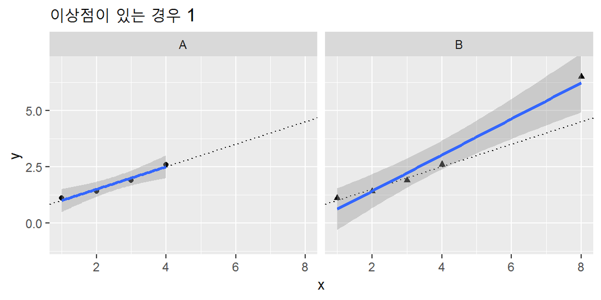

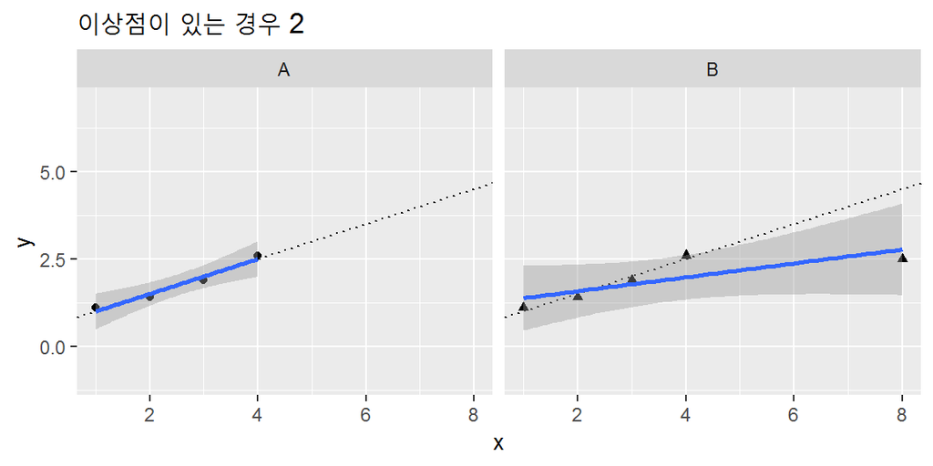

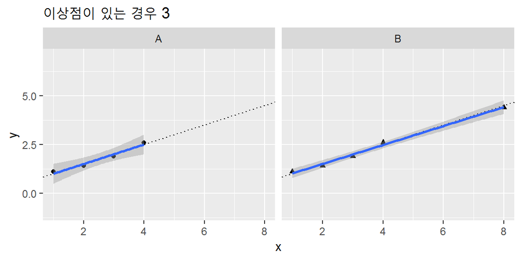

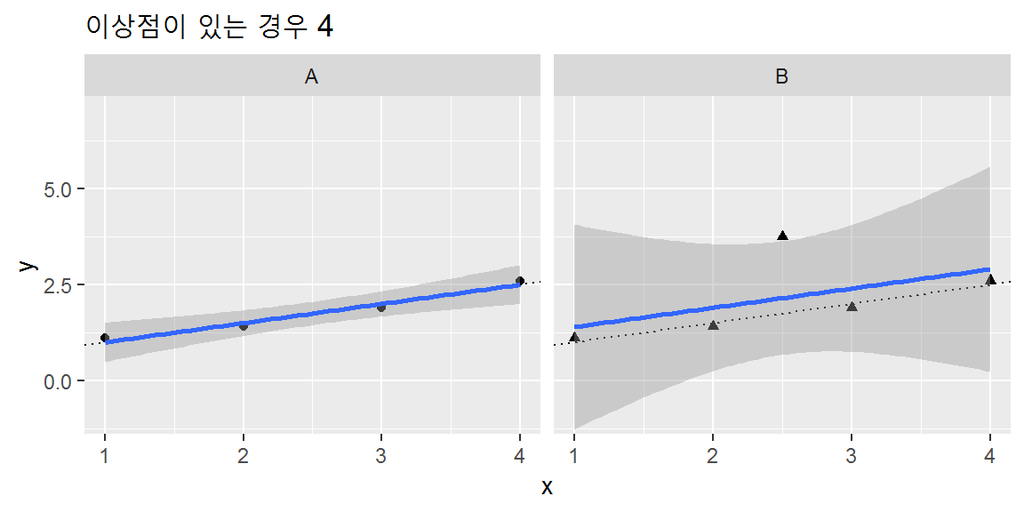

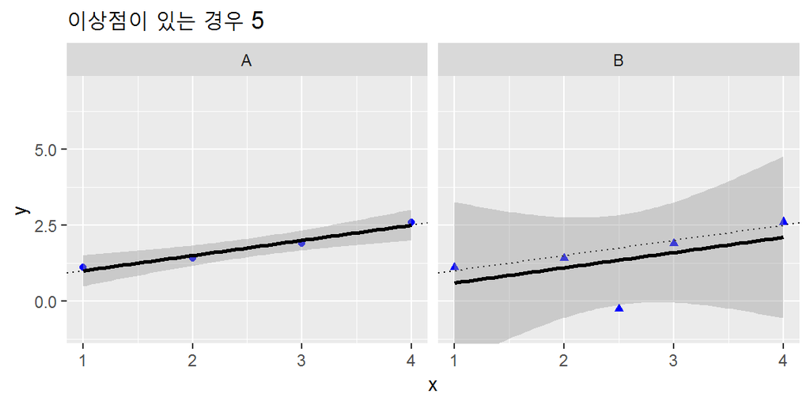

### 비선형적 관계인 경우

- 예측변수 또는 결과변수를 변환(transformation)할 수 있다.
  - 이때 LINE의 가정이 어떻게 변하는지 유의하자.
  - 자주 쓰이는 변환 함수 : $\log x$, $\frac{1}{x}$, $\sqrt{x}$, $x^2$, …

### 상관계수(Correlation Coefficient)

$$r_{xy} = \frac{\sum_{i=1}^n (x_i - \hat{x})(y_i - \hat{y})}{(n-1)s_x s_y}$$

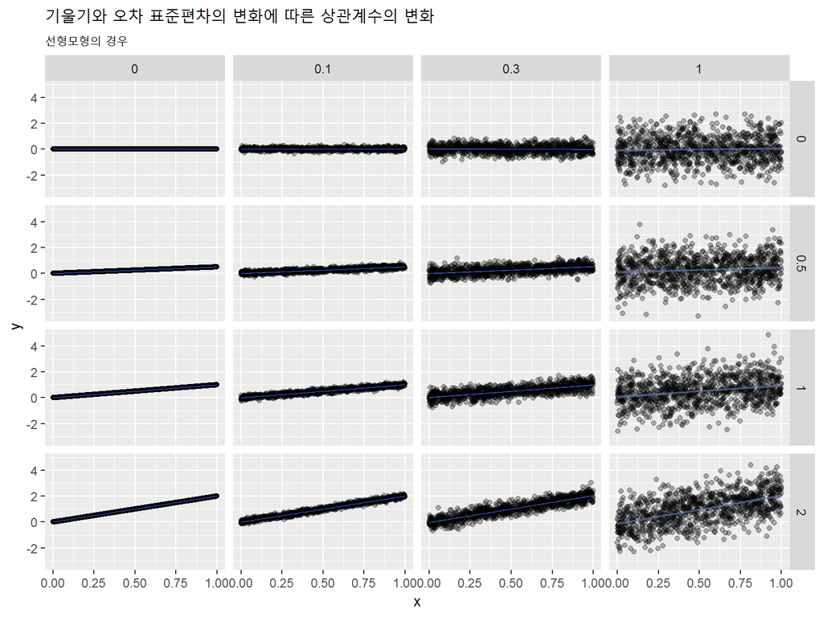

```
##   beta  0    0.1     0.3      1
## 1  0.0 NA 0.0294 -0.0453 0.0399
## 2  0.5  1 0.8170  0.4851 0.1087
## 3  1.0  1 0.9452  0.6786 0.2493
## 4  2.0  1 0.9853  0.9000 0.5468
```

### 문제

- http://data.princeton.edu/wws509/datasets/#salary의 자료를 통해 `sl`와 `yd`의 관계를 선형 회귀로 분석하시오.
- 예측변수와(또는) 결과변수를 변환(transformation)한 후에 회귀 분석을 할 때, 위에서 설명한 LINE 가정은 어떻게 바뀌는지 설명하시오.

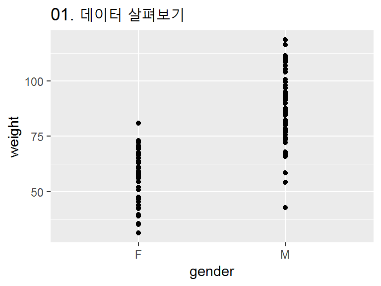

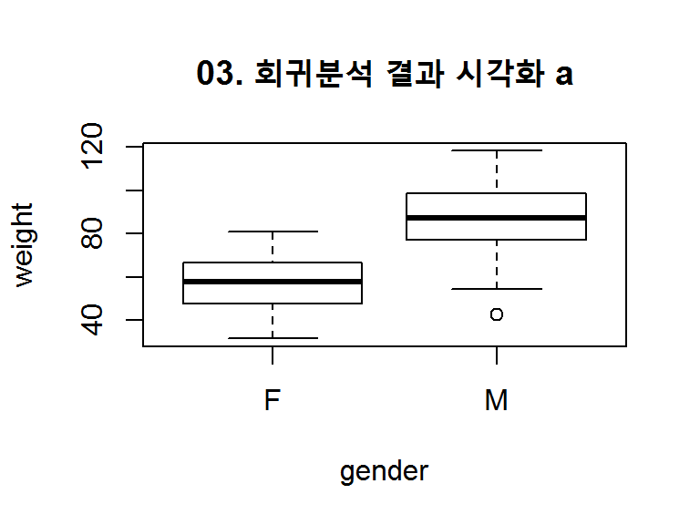

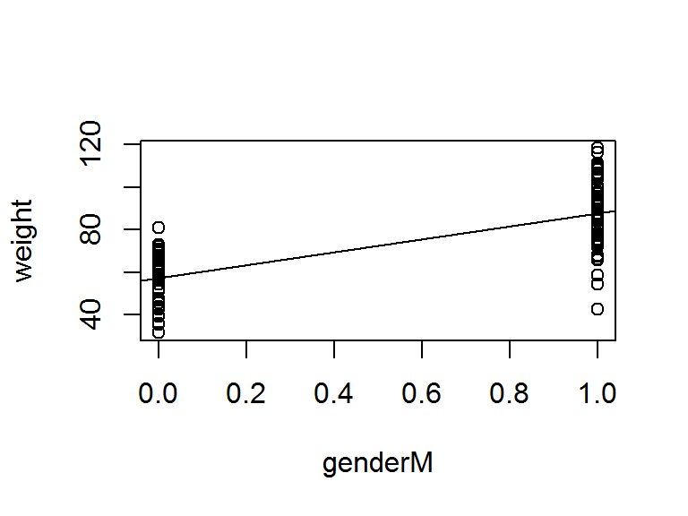

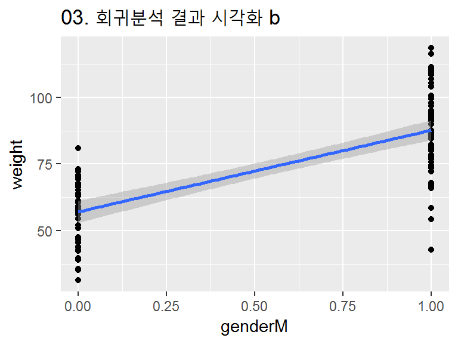

```r
library(ggplot2)
getwd()
## [1] "G:/git/MJU-2018-02-DataScience/00_Instructor/W11_MultipleRegression"
dat <- read.csv(file='./LR_weight_n100.csv', header=T, row.names=1)

# 01. 데이터 살펴보기
ggplot(dat, aes(x= gender, y=weight)) + geom_point() + labs(title="01. 데이터 살펴보기")

# 02. 회귀분석
fitLm <- lm(weight ~ gender, dat)
print(fitLm)
##
## Call:
## lm(formula = weight ~ gender, data = dat)
##
## Coefficients:
## (Intercept)      genderM
##       57.17        30.52
print(summary(fitLm))
##
## Call:
## lm(formula = weight ~ gender, data = dat)
##
## Residuals:
##     Min      1Q  Median      3Q     Max
## -44.832  -9.781   0.613   9.990  30.725
##
## Coefficients:
##             Estimate Std. Error t value Pr(>|t|)
## (Intercept)   57.172      2.108   27.13   <2e-16 ***
## genderM       30.523      2.842   10.74   <2e-16 ***
## ---
## Signif. codes:  0 '***' 0.001 '**' 0.01 '*' 0.05 '.' 0.1 ' ' 1
##
## Residual standard error: 14.14 on 98 degrees of freedom
## Multiple R-squared:  0.5407, Adjusted R-squared:  0.536
## F-statistic: 115.4 on 1 and 98 DF,  p-value: < 2.2e-16

# 03. 회귀분석 결과를 시각화하기
## a
plot(weight ~ gender, dat, main='03. 회귀분석 결과 시각화 a');
datModel <- model.matrix(~gender+weight, dat)

plot(weight ~ genderM, datModel)
fitLmModel <- lm(weight ~ genderM, data.frame(datModel))
abline(fitLmModel)

## b
ggplot(data.frame(datModel), aes(x=genderM, y=weight)) + geom_point() +
  geom_smooth(method="lm") + labs(title='03. 회귀분석 결과 시각화 b')
```

### 두 단순 선형 모형을 평가하기

- 실제 $y$와 예측된 $y$의 차이
  - 평균제곱오차(MSE; Mean Squared Error) : $\frac{\sum{(\hat{y_i}-y_i)^2}}{n}$
  - 제곱근평균제곱오차(RMSE; Root Mean Squared Error) : $\sqrt{\frac{(\sum{\hat{y_i}-y_i)^2}}{n}}$
  - 평균절대오차(MAE; Mean Absolute Error) : $\frac{\sum{|\hat{y_i}-y_i|}}{n}$
- 전체 분산 중에서 설명된 분산의 비율
  - 결정계수(the coefficient of determination) : $R^2 = \mathbb{C}or(y, \hat{y})^2 = \frac{\mathbb{V}\text{ar}[y]-\text{MSE}}{\mathbb{V}\text{ar}[y]}$

```r
library(caret) #https://stackoverflow.com/questions/53272166/cant-install-caret-package-in-r
## Loading required package: lattice
# 01. lm(weight ~ height, dat)과 lm(weight ~ gender, dat)
dat <- read.csv(file='./LR_weight_n100.csv', header=T, row.names=1)
fitA <- lm(weight ~ height, dat)
fitB <- lm(weight ~ gender, dat)

# 02. 모형 평가
## MSE
mean((dat$weight - predict(fitA))^2)
## [1] 152.8368
mean((dat$weight - predict(fitB))^2)
## [1] 195.8862

## RMSE
RMSE(dat$weight, predict(fitA)) #sqrt(mean((dat$weight - predict(fitA))^2))
## [1] 12.36272
RMSE(dat$weight, predict(fitB)) #sqrt(mean((dat$weight - predict(fitB))^2))
## [1] 13.99593

## MAE
MAE(dat$weight, predict(fitA))
## [1] 9.88135
RMSE(dat$weight, predict(fitB))
## [1] 13.99593

## 결정계수
summary(fitA)$r.squared # cor(dat$weight, predict(fitA))^2
## [1] 0.6416205
summary(fitB)$r.squared
## [1] 0.540676
```